# Shark Attack Research

Project Team 3 : Shashikant Jaiswal, Rashi Jain, Priyanka Taneja, Ryan Scolaro

31 July 2018

[figure not shown]

# **1. Overview**

## **1.1 Introduction**

This analysis is to continue the research on the presence of sharks during the tourist seasons in middle Atlantic and south eastern coastal waters using data mining following the Cross Industry Standard Process for data mining(CRISP-DM). Our study will focus on the analysis of existing data from the International Shark Attack database, weather data from NOAA and calculated moon phase dates. Based on the understanding, a model will be built to uncover various interesting facts about the impact of environmental factors such as moon phases, wind speed and wind direction on creating the favorable conditions for the sharks near the shore. The results of the study could be used to predict the likelihood of Sharks near the shore which could be used as the basis for an application or dashboard which would serve as a warning system near coastal waters with higher plausibility of human activity such as swimming, fishing etc. The Shark Protection Organizations can also make use of such a warning system to take necessary preventive measures for protecting sharks from being slaughtered by humans and thereby saving them from possible extinction.

## **1.2 Domain Understanding**

It is possible to lessen the likelihood of shark incidents by understanding shark attacks. Humans need to recognize and avoid potentially dangerous situations in the water. The individual case histories provide insights about specific geographical areas and their indigenous species of sharks. However, when all known case histories worldwide are examined, much is revealed about species behavior, and specific patterns emerge. Some accidents are motivated by a displacement or territorial behavior when a shark feels threatened; still others are the result of the shark responding to sensory predatory input (i.e., overwhelmed by the presence of many fishes) and environmental conditions (murky water), which may cause them to respond in a reflexive response to stimuli.

**1.2.1 Moon Phases** When the moon and sun align, known as full or new moon, the pull is at its strongest, causing the tides to be at their highest and lowest. This is known as spring tides. The change from high tides to low tides and back again happens very quickly which may cause sharks to move in areas closer to where people swim when the tide is low. The effect on tides occurs over a span of days leading up to the change in the lunar cycle. The effect duration, therefore, is not on the day that is typically depicted as the new or full moon, but can span several days before and after favors shark attacks.

**1.2.2 Weather Data** How shark deals with the extreme weather. As the temperature of the water in-creases, the sharks tend to move into new locations where they will be more comfortable. This means they can be in areas where people are fishing, boating, and swimming.

## **1.3 Project Links**

Click here for the [Project Link](http://www.sharkattackfile.net/)

# **2. Data Understanding**

## **2.1 Data Collection**

**Shark Data :** The principal data source for the incident of shark attack in North Carolina, South Carolina, Virginia and Georgia was taken from the incident log of the Shark research Institute defined as the “Global Shark Attack File” (GSAF). The project constrained the study of incidences of shark attacks to be limited from 2016 to 2017 for the months of May to September and from months of May to July for 2018. Since the data of attack were very less during these years, inorder to balance the data more attack cases were added from 2009-2016 to the dataset.  
**Moon phases:** Moon phases data for the selected month is collected by using lunar library of R.

```r
#library(lunar)
#shark.data$moonphase <- lunar.phase(as.Date(shark.data$Date),name=8)
```

Following values are achieved by running the code: Waxing Crescent, First Quarter, Waxing Gibbous, Full moon, Waning Gibbous, Third Quarter, and finally Waxing Crescent.

**Weather Data :** Wind speed, Daily Average wind direction, Daily precipitation, Daily Average dew point temperature, Daily Average temp are collected from Weather Underground Datasource.

# **3. Strategy**

## **3.1 Methods**

The methodology adopted for the project was the usage of CRISP-DM model.  
The data is collected from different sources and merged with global shark attack file primarily by date. The global shark attack files shows only the dates when attack happened, so in order to better train the model about the presence or the absence of the shark near sea shore, more dates in the dataset are populated and the moon phase and weather conditions of specific region i.e. buxton is recorded so as to gain knowledge based on documented attacks. If the attack did not happen then the corresponding columns are filled with NA values.

# **4. Exploratory Data Analysis**

## **4.1 Summary of Dataset**

```r
shark.data <- read.csv(file="SharkAttackData31stJuly2018_V4.csv", header=T, na.strings = c("NA",""," "), stringsAsFactors = F)
attach(shark.data)
#library(lunar)
str(shark.data)
```

```
## 'data.frame':    454 obs. of  27 variables:
##  $ Sno                    : int  1 2 3 4 5 6 7 8 9 10 ...
##  $ Date                   : chr  "7/22/2009" "9/12/2009" "6/25/2010" "6/25/2010" ...
##  $ Wd.Direction           : chr  "ESE" "SSW" "SW" "SW" ...
##  $ moonphase              : chr  "New" "Third quarter" "Full" "Full" ...
##  $ Case.Number            : chr  "2009.07.22.b" "2009.09.12" "2010.06.25.a" "2010.06.25.b" ...
##  $ Year                   : int  2009 2009 2010 2010 2010 2010 2010 2010 2011 2011 ...
##  $ Type                   : chr  "Unprovoked" "Invalid" "Unprovoked" "Unprovoked" ...
##  $ Country                : chr  "USA" "USA" "USA" "USA" ...
##  $ Area                   : chr  "North Carolina" "North Carolina" "North Carolina" "South Carolina" ...
##  $ Location               : chr  "Holden Beach, Brunswick County" "Corolla, Currituck County" "Topsail Island, Pender County" "Fripp Island, Beaufort County" ...
##  $ Activity               : chr  "Swimming" "Swimming" "Swimming" "Boogie Boarding" ...
##  $ Name                   : chr  "Julia Anne Mittleberg" "Richard A Snead" "Carley Schlentz" "Ella Morris" ...
##  $ Sex                    : chr  "F" "M" "F" "F" ...
##  $ Age                    : chr  "26" "60" "13" "6" ...
##  $ jury                   : chr  "Laceration to left foot" "FATAL" "Laceration to left foot" "Laceration to leg" ...
##  $ atal..Y.N.             : chr  "N" "Y" "N" "N" ...
##  $ Time                   : chr  "15h00" "21h00" "13h00" NA ...
##  $ Species                : chr  NA "Shark involvement prior to death not confirmed" NA NA ...
##  $ vestigator.or.Source   : chr  "C. Creswell, GSAF" "C. Creswell, GSAF  " "C. Creswell, GSAF" "C. Creswell, GSAF" ...
##  $ Attack                 : chr  "Yes" "Yes" "Yes" "Yes" ...
##  $ Hours                  : chr  "15" "21" "13" "0" ...
##  $ X                      : logi  TRUE TRUE TRUE TRUE TRUE TRUE ...
##  $ time.o.attack          : chr  "Day" "Dusk" "Day" "Dawn" ...
##  $ DailyPrecipitation     : num  0.31 0 0 0 1 0 0 0 0 0 ...
##  $ DailyAverageWdSpeed    : num  6.8 5.2 8.4 11.4 15.2 14.8 13 5.8 9.2 6 ...
##  $ DailyAverageDewPotTemp : num  71 66 76 77 77 76 79 76 NA NA ...
##  $ DailyAverageTemperature: num  79 70 80 86 76 84 86 81 82 83 ...
```

```r
shark.data <- shark.data[,-c(5,7,8,11,12,13,14,15,16,18,19,21,22)]

#shark.data$moonphase <- lunar.phase(as.Date(shark.data$Date),name=8)
summary(shark.data)
```

```
##       Sno            Date           Wd.Direction        moonphase
##  Min.   :  1.0   Length:454         Length:454         Length:454
##  1st Qu.:114.2   Class :character   Class :character   Class :character
##  Median :227.5   Mode  :character   Mode  :character   Mode  :character
##  Mean   :227.5
##  3rd Qu.:340.8
##  Max.   :454.0
##
##       Year          Area             Location             Time
##  Min.   :2009   Length:454         Length:454         Length:454
##  1st Qu.:2016   Class :character   Class :character   Class :character
##  Median :2017   Mode  :character   Mode  :character   Mode  :character
##  Mean   :2016
##  3rd Qu.:2017
##  Max.   :2018
##
##     Attack          time.o.attack      DailyPrecipitation
##  Length:454         Length:454         Min.   :0.0000
##  Class :character   Class :character   1st Qu.:0.0000
##  Mode  :character   Mode  :character   Median :0.0000
##                                        Mean   :0.1981
##                                        3rd Qu.:0.0900
##                                        Max.   :3.9000
##                                        NA's   :32
##  DailyAverageWdSpeed DailyAverageDewPotTemp DailyAverageTemperature
##  Min.   : 0.000      Min.   :43.3           Min.   :56.20
##  1st Qu.: 2.000      1st Qu.:68.4           1st Qu.:74.90
##  Median : 4.000      Median :73.0           Median :77.70
##  Mean   : 4.425      Mean   :71.4           Mean   :77.04
##  3rd Qu.: 6.000      3rd Qu.:76.0           3rd Qu.:80.20
##  Max.   :19.800      Max.   :80.3           Max.   :90.50
##                      NA's   :45
```

## **4.2 Missing Data**

The missing data observed for the dataset is as follows:

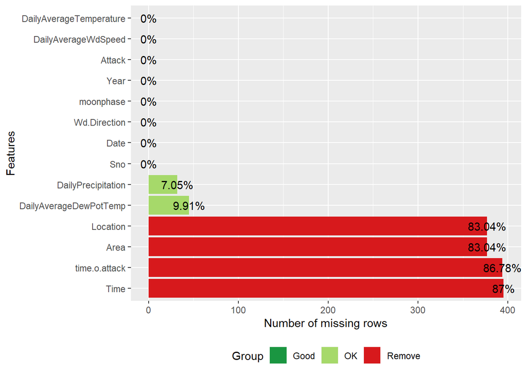

```r
plot_missing(shark.data)
```

## **4.3 Location**

It can be seen from the below graph that the most vulnerable county for Shark Attack is **Horry and Charleston** among the locations of South and North Carolina.

```
##  [1] "Brunswick"   "Currituck"   "Pender"      "Beaufort"    "New Hanover"
##  [6] "Horry"       "Charleston"  "New Hanover" "Hyde"        "Beaufort"
## [11] "Horry"       "New Hanover" "New Hanover" "Dare"        "Brunswick"
## [16] "Horry"       "Dare"        "Horry"       "Horry"       "Horry"
## [21] "Horry"       "Horry"       "Brunswick"   "Horry"       "Onslow"
## [26] "Brunswick"   "Horry"       "Charleston"  "Brunswick"   "Charleston"
## [31] "Charleston"  "Beaufort"    "Beaufort"    "Charleston"  "New Hanover"
## [36] "Brunswick"   "Charleston"  "New Hanover" "New Hanover" "Horry"
## [41] "Charleston"  "Brunswick"   "Brunswick"   "Brunswick"   "Beaufort"
## [46] "Pender"      "Dare"        "Beaufort"    "Dare"        "Charleston"
## [51] "Hyde"        "Pender"      "Colleton"    "Georgetown"  "Horry"
## [56] "Charleston"  "Charleston"  "Carteret"    "Carteret"    "Horry"
## [61] "Horry"       "Carteret"    "Carteret"    "Charleston"  "Charleston"
## [66] "Horry"       "Horry"       "Charleston"  "Beaufort"    "Beaufort"
## [71] "New Hanover" "Beaufort"    "Georgetown"  "Beaufort"    "Beaufort"
## [76] "Beaufort"    "Charleston"
```

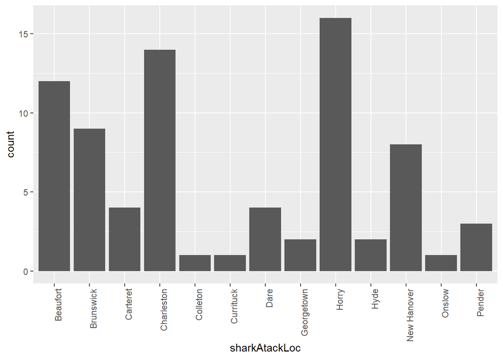

## **4.4 Wind Direction**

The given data showed that maximum number of Shark attack occured when the wind was flowing in **SSW and SW**.  
**When Attack Occurred**

```r
windDirection <- shark.data$Wd.Direction[shark.data$Attack== "Yes"]
windDirection
```

```
##  [1] "ESE" "SSW" "SW"  "SW"  "SW"  "SW"  "SW"  "E"   "SSW" "SSE" "SSW"
## [12] "E"   "E"   "SE"  "SE"  "E"   "SSW" "SSE" "NNE" "NNE" "NNE" "NNE"
## [23] "SE"  "S"   "SE"  "WSW" "NE"  "SSW" "SSW" "SE"  "SSW" "SSW" "SW"
## [34] "ESE" "SSE" "WSW" "SSW" "NE"  "E"   "E"   "E"   "S"   "SSW" "SSW"
## [45] "SW"  "SW"  "SSW" "SSW" "SW"  "SSW" "SW"  "SW"  "E"   "SW"  "SW"
## [56] "SW"  "W"   "WSW" "WSW" "WSW" "WSW" "SE"  "NE"  "S"   "ENE" "WSW"
## [67] "S"   "WSW" "SW"  "WSW" "S"   "S"   "WSW" "WSW" "ENE" "SW"  "WSW"
```

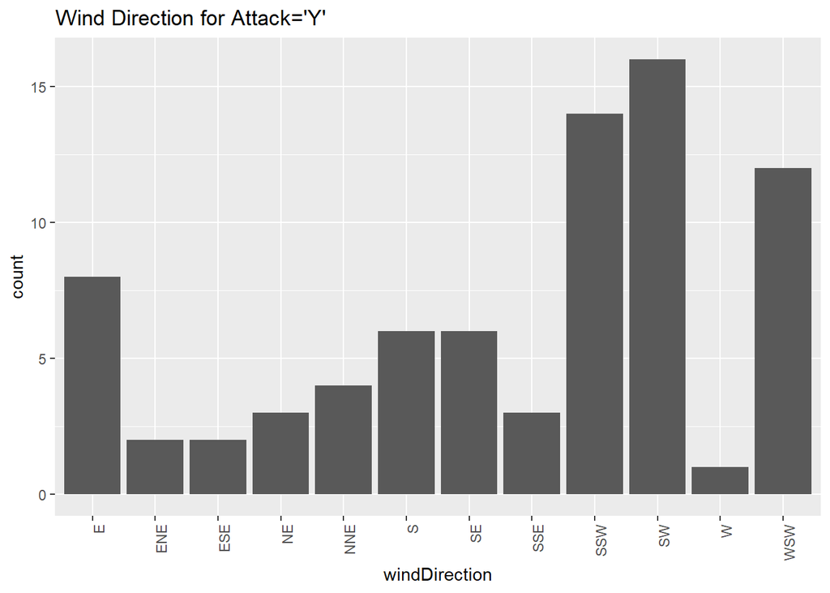

```r
# counts
ggplot(data.frame(windDirection), aes(x=windDirection)) +
  geom_bar()+theme(axis.text.x = element_text(angle = 90, hjust = 1)) + ggtitle("Wind Direction for Attack='Y'")
```

**Overlayed Bar Chart for Wind Direction and Attack**

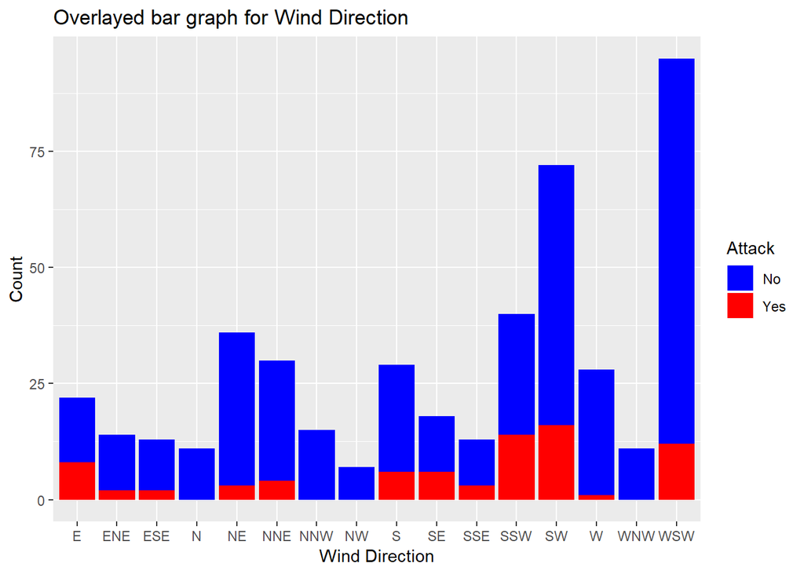

```r
ggplot() +
  geom_bar(data = shark.data,
           aes(x = factor(shark.data$Wd.Direction),
               fill = factor(shark.data$Attack)),
           position = "stack") +
  scale_x_discrete("Wind Direction") +
  scale_y_continuous("Count") +
  guides(fill=guide_legend(title="Attack")) +
  scale_fill_manual(values=c("blue", "red")) + ggtitle("Overlayed bar graph for Wind Direction")
```

## **4.6 Moon Phases**

Maximum shark attacks happened in New Moon phase. During the waxing gibbous and waning crescent phases, the Moon is approaching its full and new phases, respectively. Because of this, the resulting tidal bulges will increase in size until they reach their maximum during the spring tides.

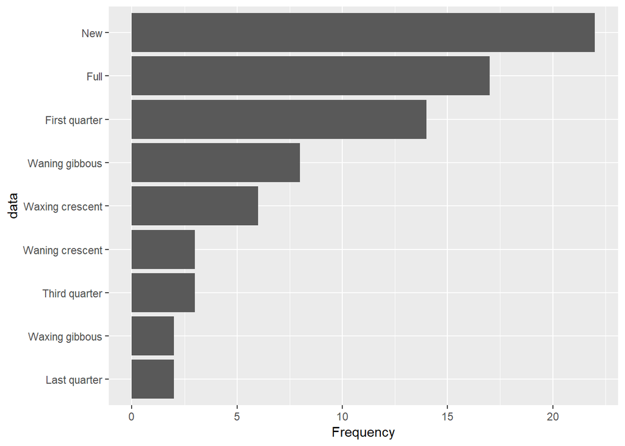

```r
##### selecting the records in which attack has happened for EDA
shark.data_attack <- subset(shark.data, shark.data$Attack=="Yes")
plot_bar(shark.data_attack$moonphase)
```

## **4.7 Density Graph for the Shark Attack Data**

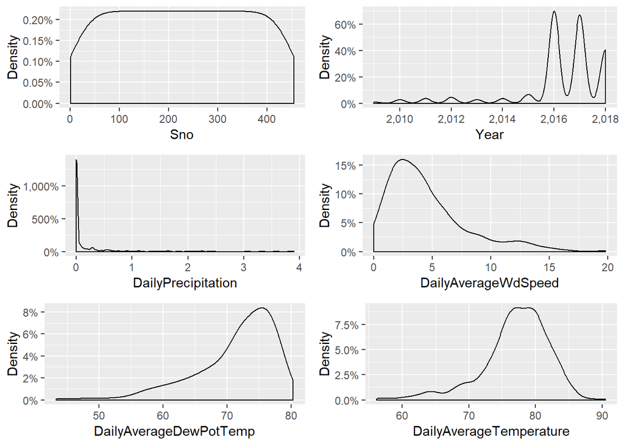

```r
plot_density(shark.data)
```

## **4.8 Understanding the Correlation**

Checking for the correlation between the attributes.

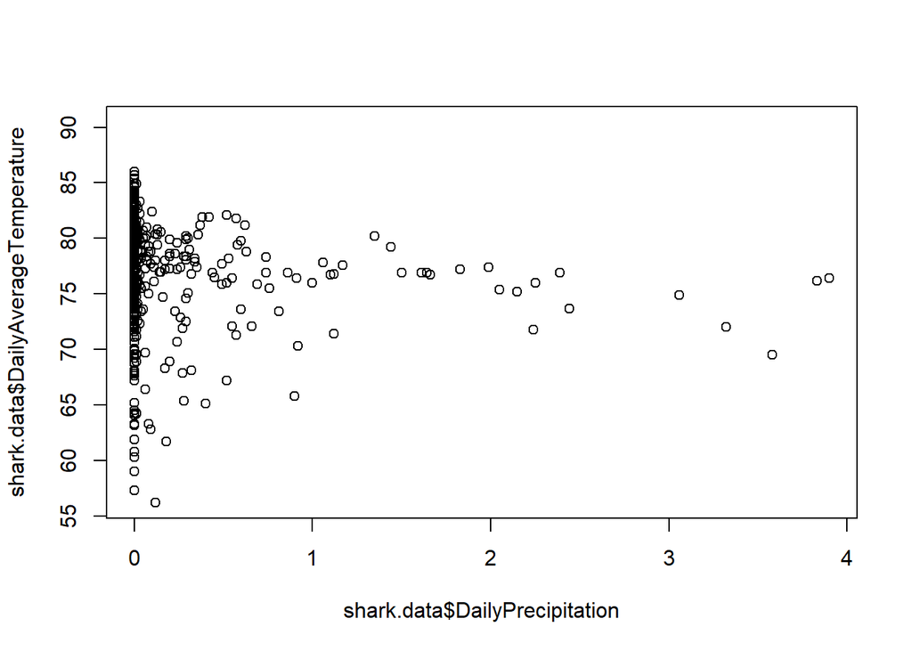

```r
plot(shark.data$DailyPrecipitation, shark.data$DailyAverageTemperature)
```

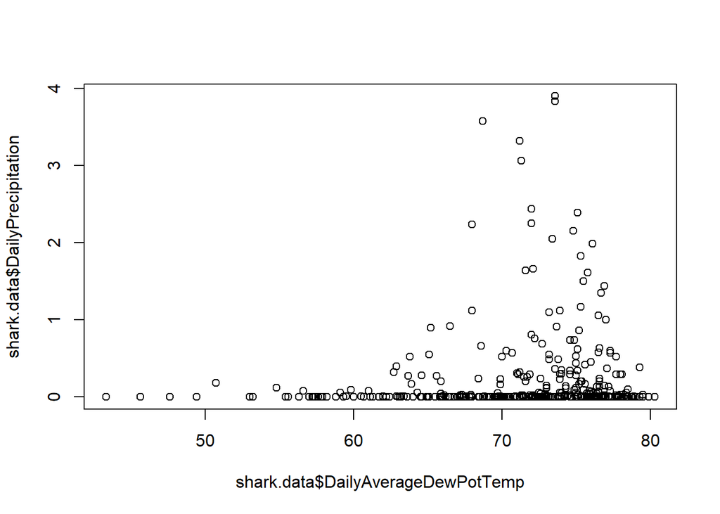

```r
plot(shark.data$DailyAverageDewPotTemp, shark.data$DailyPrecipitation)
```

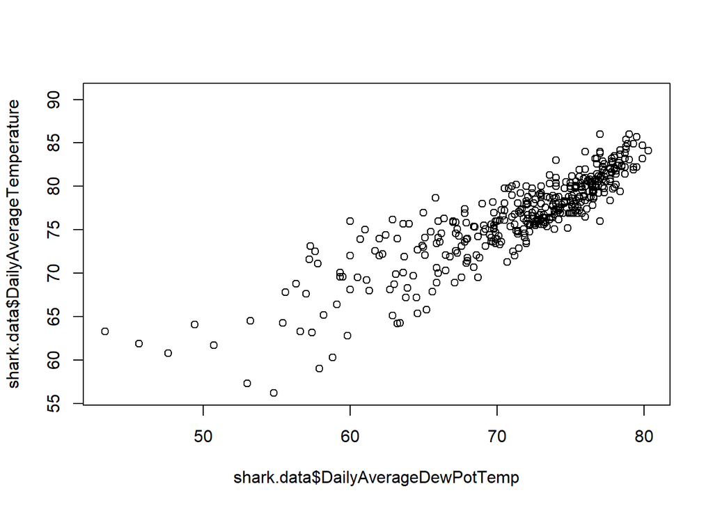

```r
plot(shark.data$DailyAverageDewPotTemp, shark.data$DailyAverageTemperature)
```

DailyAverageTemperature and DailyAverageDewPotTemp are probably related as the average temperature should influence the dew temperature it makes sense to check for a correlation between the two.

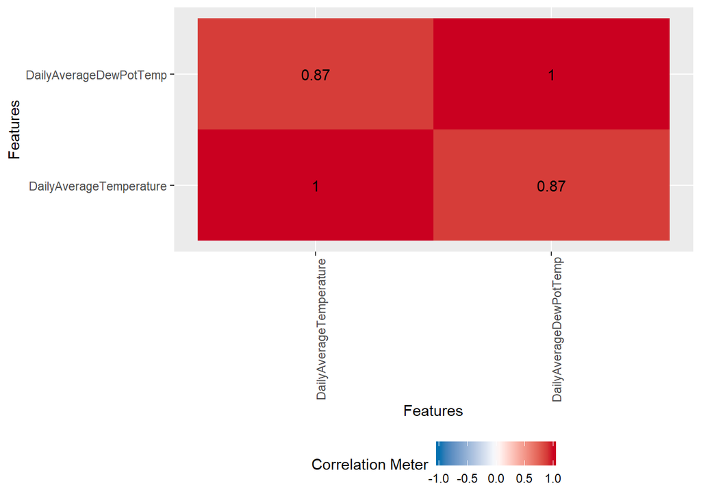

```r
plot_correlation(shark.data[,c("DailyAverageTemperature", "DailyAverageDewPotTemp")], use = "pairwise.complete.obs")
```

The plot indicates that the two variables are indeed correlated strongly so it is likely that one of them may be left out during modeling.

# **5. Data Preparation**

The data for Shark Attack has been colleced for three years during the tourist period from various sources and have been integrated. Raw data was noisy and unfit to run models on them. Country column was a unary attribute with value USA for all the records and can be easily removed. Therefore, following data preparation steps were taken for data cleaning:

## **5.1 Handling Outliers**

Our first setep was to check for missing values in the four columns.

```r
sapply(shark.data[,c("DailyAverageTemperature", "DailyAverageDewPotTemp", "DailyAverageWdSpeed", "DailyPrecipitation")], function(x) sum(is.na(x)))
```

```
## DailyAverageTemperature  DailyAverageDewPotTemp     DailyAverageWdSpeed
##                       0                      45                       0
##      DailyPrecipitation
##                      32
```

After removing the rows with missing data we check each variable for outliers using the zscore method.

**DailyAverageTemperature**

```r
shark.data.removedNAs <- shark.data[!is.na(shark.data$DailyAverageTemperature),]
shark.data.removedNAs$zscore.DailyAverageTemperature <- (shark.data.removedNAs$DailyAverageTemperature - mean(shark.data.removedNAs$DailyAverageTemperature))/sd(shark.data.removedNAs$DailyAverageTemperature)
cat("Number of lower range outliers: ", length(shark.data.removedNAs$zscore.DailyAverageTemperature[shark.data.removedNAs$zscore.DailyAverageTemperature < -3]))
```

```
## Number of lower range outliers:  7
```

```r
cat("Number of upper range outliers: ", length(shark.data.removedNAs$zscore.DailyAverageTemperature[shark.data.removedNAs$zscore.DailyAverageTemperature > 3]))
```

```
## Number of upper range outliers:  0
```

**DailyAverageDewPotTemp**

```r
shark.data.removedNAs<- shark.data[!is.na(shark.data$DailyAverageDewPotTemp),]
shark.data.removedNAs$zscore.DailyAverageDewPotTemp <- (shark.data.removedNAs$DailyAverageDewPotTemp - mean(shark.data.removedNAs$DailyAverageDewPotTemp))/sd(shark.data.removedNAs$DailyAverageDewPotTemp)
cat("Number of lower range outliers: ", length(shark.data.removedNAs$zscore.DailyAverageDewPotTemp[shark.data.removedNAs$zscore.DailyAverageDewPotTemp < -3]))
```

```
## Number of lower range outliers:  5
```

```r
cat("Number of upper range outliers: ", length(shark.data.removedNAs$zscore.DailyAverageDewPotTemp[shark.data.removedNAs$zscore.DailyAverageDewPotTemp > 3]))
```

```
## Number of upper range outliers:  0
```

**DailyAverageWdSpeed**

```r
shark.data.removedNAs<- shark.data[!is.na(shark.data$DailyAverageWdSpeed),]
shark.data.removedNAs$zscore.DailyAverageWdSpeed <- (shark.data.removedNAs$DailyAverageWdSpeed - mean(shark.data.removedNAs$DailyAverageWdSpeed))/sd(shark.data.removedNAs$DailyAverageWdSpeed)
cat("Number of lower range outliers: ", length(shark.data.removedNAs$zscore.DailyAverageWdSpeed[shark.data.removedNAs$zscore.DailyAverageWdSpeed < -3]))
```

```
## Number of lower range outliers:  0
```

```r
cat("Number of upper range outliers: ", length(shark.data.removedNAs$zscore.DailyAverageWdSpeed[shark.data.removedNAs$zscore.DailyAverageWdSpeed > 3]))
```

```
## Number of upper range outliers:  6
```

**DailyPrecipitation**

```r
shark.data.removedNAs<- shark.data[!is.na(shark.data$DailyPrecipitation),]
shark.data.removedNAs$zscore.DailyPrecipitation <- (shark.data.removedNAs$DailyPrecipitation - mean(shark.data.removedNAs$DailyPrecipitation))/sd(shark.data.removedNAs$DailyPrecipitation)
cat("Number of lower range outliers: ", length(shark.data.removedNAs$zscore.DailyPrecipitation[shark.data.removedNAs$zscore.DailyPrecipitation < -3]))
```

```
## Number of lower range outliers:  0
```

```r
cat("Number of upper range outliers: ", length(shark.data.removedNAs$zscore.DailyPrecipitation[shark.data.removedNAs$zscore.DailyPrecipitation > 3]))
```

```
## Number of upper range outliers:  13
```

All four columns have very few outliers so we decided to check the actual max and min values in each column.

```r
summary(shark.data.removedNAs[,c("DailyAverageTemperature", "DailyAverageDewPotTemp", "DailyAverageWdSpeed", "DailyPrecipitation")])
```

```
##  DailyAverageTemperature DailyAverageDewPotTemp DailyAverageWdSpeed
##  Min.   :56.20           Min.   :43.3           Min.   : 0.000
##  1st Qu.:74.62           1st Qu.:68.4           1st Qu.: 2.000
##  Median :77.35           Median :73.0           Median : 3.000
##  Mean   :76.73           Mean   :71.4           Mean   : 4.033
##  3rd Qu.:80.00           3rd Qu.:76.0           3rd Qu.: 5.000
##  Max.   :86.00           Max.   :80.3           Max.   :16.600
##                          NA's   :13
##  DailyPrecipitation
##  Min.   :0.0000
##  1st Qu.:0.0000
##  Median :0.0000
##  Mean   :0.1981
##  3rd Qu.:0.0900
##  Max.   :3.9000
##
```

None of the max or min values are out of the ordinary for weather patterns so it is very likely they are correct. For this reason we decided to leave the outliers alone for now, altough we may remove them at a later stage if needed.

## **5.2 Missing Data Handling**

Data had some missing values which was a hinderance for normalization of the data. In order to make data fit for modelling these missing data was replaced by **Imputed Values** using Mice.

```r
#Store the Numeric Columns with Missing Values in temporary dataset
str(shark.data)
```

```
## 'data.frame':    454 obs. of  15 variables:
##  $ Sno                    : int  1 2 3 4 5 6 7 8 9 10 ...
##  $ Date                   : chr  "7/22/2009" "9/12/2009" "6/25/2010" "6/25/2010" ...
##  $ Wd.Direction           : chr  "ESE" "SSW" "SW" "SW" ...
##  $ moonphase              : chr  "New" "Third quarter" "Full" "Full" ...
##  $ Year                   : int  2009 2009 2010 2010 2010 2010 2010 2010 2011 2011 ...
##  $ Area                   : chr  "North Carolina" "North Carolina" "North Carolina" "South Carolina" ...
##  $ Location               : chr  "Holden Beach, Brunswick County" "Corolla, Currituck County" "Topsail Island, Pender County" "Fripp Island, Beaufort County" ...
##  $ Time                   : chr  "15h00" "21h00" "13h00" NA ...
##  $ Attack                 : chr  "Yes" "Yes" "Yes" "Yes" ...
##  $ time.o.attack          : chr  "Day" "Dusk" "Day" "Dawn" ...
##  $ DailyPrecipitation     : num  0.31 0 0 0 1 0 0 0 0 0 ...
##  $ DailyAverageWdSpeed    : num  6.8 5.2 8.4 11.4 15.2 14.8 13 5.8 9.2 6 ...
##  $ DailyAverageDewPotTemp : num  71 66 76 77 77 76 79 76 NA NA ...
##  $ DailyAverageTemperature: num  79 70 80 86 76 84 86 81 82 83 ...
##  $ County                 : chr  "Brunswick" "Currituck" "Pender" "Beaufort" ...
```

```r
shark.data.temp <- shark.data[,-c(1,2,3,4,5,6,7,8,9,10,15,16,17,18,19)]
# added column 2(date) which will be used to merge imputed data with original data
sapply(shark.data.temp, function(x) sum(is.na(x)))
```

```
##      DailyPrecipitation     DailyAverageWdSpeed  DailyAverageDewPotTemp
##                      32                       0                      45
## DailyAverageTemperature
##                       0
```

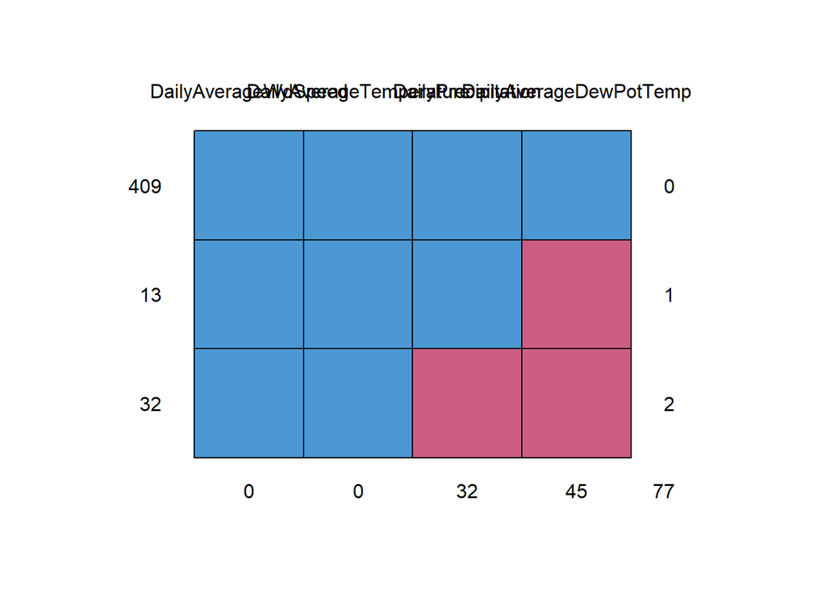

```
##     DailyAverageWdSpeed DailyAverageTemperature DailyPrecipitation
## 409                   1                       1                  1
## 13                    1                       1                  1
## 32                    1                       1                  0
##                       0                       0                 32
##     DailyAverageDewPotTemp
## 409                      1  0
## 13                       0  1
## 32                       0  2
##                         45 77
```

```r
#Run Mice to impute the data
md.pattern(shark.data.temp)
```

**Mice Plot for Missing Data**

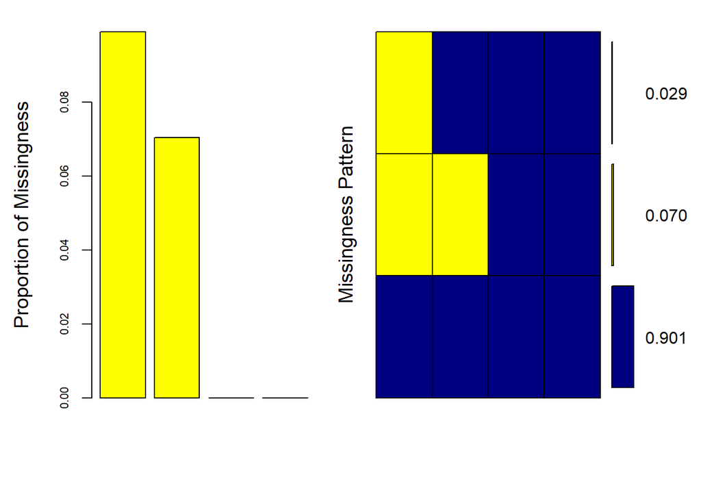

```
##
##  Variables sorted by number of missings:
##                 Variable      Count
##   DailyAverageDewPotTemp 0.09911894
##       DailyPrecipitation 0.07048458
##      DailyAverageWdSpeed 0.00000000
##  DailyAverageTemperature 0.00000000
```

```r
mice_plot <- aggr(shark.data.temp, col=c('navyblue','yellow'),
numbers=TRUE, sortVars=TRUE,
labels=names(shark.data.temp), cex.axis=.7,
gap=3, ylab=c("Proportion of Missingness","Missingness Pattern"))
```

```r
#Store the data with imputed values in complete_data
complete_data=complete(imputed_Data,5)
md.pattern(complete_data)
```

```
##  /\     /\
## {  `---'  }
## {  O   O  }
## ==>  V <==  No need for mice. This data set is completely observed.
##  \  \|/  /
##   `-----'
```

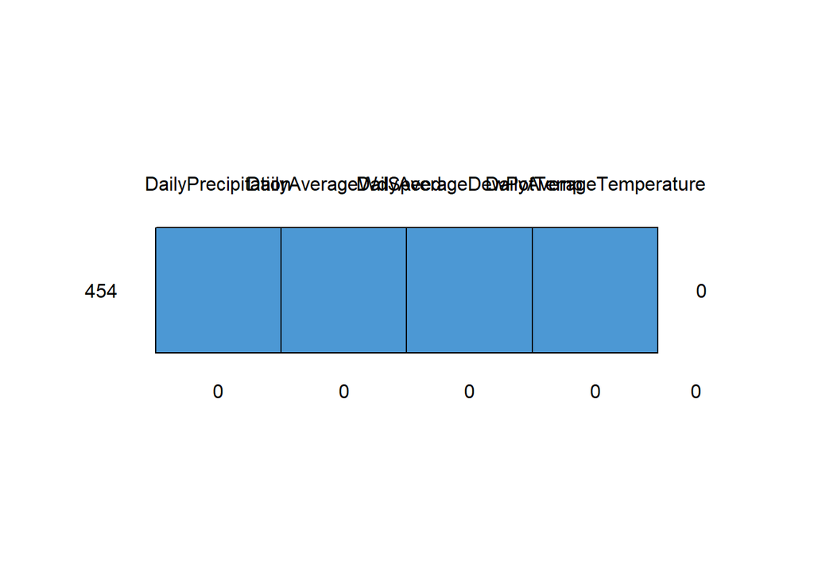

```
##     DailyPrecipitation DailyAverageWdSpeed DailyAverageDewPotTemp
## 454                  1                   1                      1
##                      0                   0                      0
##     DailyAverageTemperature
## 454                       1 0
##                           0 0
```

```r
sapply(complete_data, function(x) sum(is.na(x)))
```

```
##      DailyPrecipitation     DailyAverageWdSpeed  DailyAverageDewPotTemp
##                       0                       0                       0
## DailyAverageTemperature
##                       0
```

```r
#Add Column for imputed values the imputed values with the current dataset
shark.data$DailyAverageDewPotTemp_imputed <- complete_data$DailyAverageDewPotTemp
shark.data$DailyPrecipitation_imputed <- complete_data$DailyPrecipitation
```